# Powers of*ten*

A talk inspired by **Powers of Ten** released in *1977* a collaboration between Ray and Charles Eames and IBM. This talk was created using Jupyter Notebooks and Lab. We used RISE for our presentation.

```python
    from pydata.style import *
    %load_ext literacy.template
```

```python
https://www.youtube.com/embed/0fKBhvDjuy0
```

[video not shown]

```python
## Topics

This presentation is inspired by simple geometries.  Eventually we settled on the following key `topics\`


    = 'design, systems, materials, community, media, culture'

with the accompanying `constraints\`

    = 'functional, geographical, physical, people, sensory, time'
```

Topics

This presentation is inspired by simple geometries. Eventually we settled on the following key `topics\`

```
= 'design, systems, materials, community, media, culture'
```

with the accompanying `constraints\`

```
= 'functional, geographical, physical, people, sensory, time'
```

```python
    topics, constraints = map(lambda ___: ___.replace(' ', '').split(','),[topics, constraints])
```

```python
# [Shapes of the presentation]()
```

Shapes of the presentation

```python
    df
```

| order | constraints topic | functional | geographical | physical | people | sensory | time |
| --- | --- | --- | --- | --- | --- | --- | --- |
| 0 | design | systems | materials | community | media | culture | design |
| 1 | systems | materials | community | media | culture | design | systems |
| 2 | materials | community | media | culture | design | systems | materials |
| 3 | community | media | culture | design | systems | materials | community |
| 4 | media | culture | design | systems | materials | community | media |
| 5 | culture | design | systems | materials | community | media | culture |

```python
    Import('.Sierpinski Triangle');
```

```python
    Import('.shapes');
```

```python
# Abstracts
```

```python
{% for topic in topics[:2] %}{{the.Path().read_text().loads().get_in(['cells', 0, 'source'])[''.join](topic+'.ipynb')}}
{% endfor %}
```

```python
{% for topic in topics[2:4] %}{{the.Path().read_text().loads().get_in(['cells', 0, 'source'])[''.join](topic+'.ipynb')}}

{% endfor %}
```

```python
{% for topic in topics[4:] %}{{the.Path().read_text().loads().get_in(['cells', 0, 'source'])[''.join](topic+'.ipynb')}}
{% endfor %}
```

```python
## Particles

Particles are standalone articles and presentations that are importable.
```

# Design

> Design applies shared experience to **form**s to **function**al ideas.

```python
## _Design_ & [Systems]( "1979")
```

*Design* & Systems

```python
    Astropy = Import('.Astropy Units')
```

```python
* https://en.wikipedia.org/wiki/Timeline_of_computing_hardware_before_1950
* https://en.wikipedia.org/wiki/History_of_computing_hardware_(1960s%E2%80%93present)


![](http://i.dailymail.co.uk/i/pix/2017/04/25/16/3F952C0D00000578-4443474-image-a-105_1493135200640.jpg)
```

- https://en.wikipedia.org/wiki/Timeline_of_computing_hardware_before_1950

- https://en.wikipedia.org/wiki/History_of_computing_hardware_(1960s%E2%80%93present)

[figure not shown]

```python
https://en.m.wikipedia.org/wiki/Transatlantic_communications_cable#Private_cable_routes
```

[interactive chart not shown]

```python
![](http://www.scienceclarified.com/photos/hubble-3225.jpg)
http://www.scienceclarified.com/scitech/Telescopes/Hubble.html
```

[figure not shown]

http://www.scienceclarified.com/scitech/Telescopes/Hubble.html

```python
## _Design_ & [Materials]()

* Metals, Polymers, Ceramics
* Function, Structural
* Composite
```

*Design* & Materials

- Metals, Polymers, Ceramics

- Function, Structural

- Composite

```python
![](https://i.pinimg.com/736x/f4/97/41/f497413e4278558b62544b6a9ef25de3--tv-quotes-movie-quotes.jpg)
```

[figure not shown]

```python
    %%html
    <div class="github-card" data-user="chrislgarry" data-repo="Apollo-11"></div>
    <script src="https://cdn.jsdelivr.net/gh/lepture/github-cards@1.0.2/jsdelivr/widget.js"></script>
```

```python
## Hubble Glass

![](http://www.scienceclarified.com/scitech/images/lsts_0001_0001_0_img0028.jpg)
```

Hubble Glass

[figure not shown]

```python
## [Gorilla Glass](http://www.designlife-cycle.com/corning-gorilla-glass/)
```

[Gorilla Glass](http://www.designlife-cycle.com/corning-gorilla-glass/)

[interactive chart not shown]

```python
### [Degradation of railway rails from a materials point of view](http://publications.lib.chalmers.se/records/fulltext/173441/173441.pdf#page=15)
```

[Degradation of railway rails from a materials point of view](http://publications.lib.chalmers.se/records/fulltext/173441/173441.pdf#page=15)

[interactive chart not shown]

```python
## [Advanced High Strength Steels](https://lightmat.org/capabilities/los-alamos-national-laboratory/advanced-high-strength-steel-development)

[![](https://lightmat.org/sites/default/files/capabilities/001_2_LANL.png)](https://lightmat.org/capabilities/los-alamos-national-laboratory/advanced-high-strength-steel-development)
```

[Advanced High Strength Steels](https://lightmat.org/capabilities/los-alamos-national-laboratory/advanced-high-strength-steel-development)

[figure not shown]

```python
[![](https://image.slidesharecdn.com/flamel-ss-141210102438-conversion-gate02/95/flamel-materials-informatics-course-roundup-15-1024.jpg?cb=1418218370)](https://www.slideshare.net/tonyfast1/flamel-materials-informatics-course-roundup)
```

[figure not shown]

```python
### [High-Throughput Image Analysis of Fibrillar Materials: A Case Study on Polymer Nanofiber Packing, Alignment, and Defects in Organic Field Effect Transistors](http://pubs.acs.org/doi/abs/10.1021/acsami.7b10510)
```

[High-Throughput Image Analysis of Fibrillar Materials: A Case Study on Polymer Nanofiber Packing, Alignment, and Defects in Organic Field Effect Transistors](http://pubs.acs.org/doi/abs/10.1021/acsami.7b10510)

```python
## _Design_ & [Community]()

> Communities, and their varied forms and structures, are essential to considering other functional constraints.
```

*Design* & Community

> Communities, and their varied forms and structures, are essential to considering other functional constraints.

```python
### Philanthropic
* [Human Cell Atlas](https://www.humancellatlas.org/) ([Chan Zuckerberg](https://chanzuckerberg.com/))
```

Philanthropic

- [Human Cell Atlas](https://www.humancellatlas.org/) ([Chan Zuckerberg](https://chanzuckerberg.com/))

```python
### Government
* National Manufacturing Initiatives
* Materials By Design
* [CERN](https://home.cern)
```

Government

- National Manufacturing Initiatives

- Materials By Design

- [CERN](https://home.cern)

```python
### Public

![](https://github.com/jupyter/notebook/raw/master/notebook/static/base/images/logo.png)

# conda ![](https://conda-forge.org/img/anvil_black.png) forge
```

Public

conda forge

[figure not shown]

```python
https://www.ncbi.nlm.nih.gov/pmc/articles/PMC3878597/
https://en.m.wikipedia.org/wiki/Reproducibility#Reproducible_research
https://en.m.wikipedia.org/wiki/The_Structure_of_Scientific_Revolutions
https://en.m.wikipedia.org/wiki/LIGO_Scientific_Collaboration#History
https://www.fraunhofer.de/en.html
```

```python
## _Design_ & [Media]()

![](https://www.oldtimeradiodownloads.com/assets/img/serie/img_otr.jpg)
```

*Design* & Media

[figure not shown]

```python
> ##  [The First Web Page](http://info.cern.ch/hypertext/WWW/TheProject.html "1990")
```

> [The First Web Page](http://info.cern.ch/hypertext/WWW/TheProject.html)

[interactive chart not shown]

```python
## [Django](https://en.m.wikipedia.org/wiki/Django_%28web_framework%29)
```

[Django](https://en.m.wikipedia.org/wiki/Django_%28web_framework%29)

[interactive chart not shown]

```python
## [Particles at NYT](http://nytlabs.com/blog/2015/10/20/particles/)
```

[Particles at NYT](http://nytlabs.com/blog/2015/10/20/particles/)

[interactive chart not shown]

```python
## [d3: Data-Driven documents](https://d3js.org)
```

[d3: Data-Driven documents](https://d3js.org)

[interactive chart not shown]

```python
https://getbootstrap.com/
```

[interactive chart not shown]

```python
https://reactjs.org/
```

[interactive chart not shown]

```python
## _Design_ & [Culture]()

Our complex systems our changing and humans are adapting to displacement}

![](https://cdn.hpm.io/wp-content/uploads/2016/03/Levee-Profile.jpg)
```

*Design* & Culture

Our complex systems our changing and humans are adapting to displacement}

[figure not shown]

```python
https://www.ushahidi.com/
```

[interactive chart not shown]

```python
https://native-land.ca/


inconvenient truth

h
```

```python
http://opengeoscience.github.io/geojs/examples/hurricanes/
```

[interactive chart not shown]

```python
## _Design_ & [Design]()


![Gorilla glass makes this possible](http://cdn.hexjam.com/editorial_service/bases/images/000/004/947/large/brokenphonefeature.png-1.jpg?1404202657)
```

*Design* & Design

[figure not shown]

```python
http://www.redharebrewing.com/red-hare-launches-worlds-first-evercan/
```

[interactive chart not shown]

```python
## [Design of Experiments](https://en.m.wikipedia.org/wiki/Design_of_experiments#Fisher.27s_principles 1935)
```

Design of Experiments

[interactive chart not shown]

```python
    import sklearn.datasets
    print(sklearn.datasets.load_iris().DESCR)
```

```
Iris Plants Database
====================

Notes
-----
Data Set Characteristics:
    :Number of Instances: 150 (50 in each of three classes)
    :Number of Attributes: 4 numeric, predictive attributes and the class
    :Attribute Information:
        - sepal length in cm
        - sepal width in cm
        - petal length in cm
        - petal width in cm
        - class:
                - Iris-Setosa
                - Iris-Versicolour
                - Iris-Virginica
    :Summary Statistics:

    ============== ==== ==== ======= ===== ====================
                    Min  Max   Mean    SD   Class Correlation
    ============== ==== ==== ======= ===== ====================
    sepal length:   4.3  7.9   5.84   0.83    0.7826
    sepal width:    2.0  4.4   3.05   0.43   -0.4194
    petal length:   1.0  6.9   3.76   1.76    0.9490  (high!)
    petal width:    0.1  2.5   1.20  0.76     0.9565  (high!)
    ============== ==== ==== ======= ===== ====================

    :Missing Attribute Values: None
    :Class Distribution: 33.3% for each of 3 classes.
    :Creator: R.A. Fisher
    :Donor: Michael Marshall (MARSHALL%PLU@io.arc.nasa.gov)
    :Date: July, 1988

This is a copy of UCI ML iris datasets.
http://archive.ics.uci.edu/ml/datasets/Iris

The famous Iris database, first used by Sir R.A Fisher

This is perhaps the best known database to be found in the
pattern recognition literature.  Fisher's paper is a classic in the field and
is referenced frequently to this day.  (See Duda & Hart, for example.)  The
data set contains 3 classes of 50 instances each, where each class refers to a
type of iris plant.  One class is linearly separable from the other 2; the
latter are NOT linearly separable from each other.

References
----------
   - Fisher,R.A. "The use of multiple measurements in taxonomic problems"
     Annual Eugenics, 7, Part II, 179-188 (1936); also in "Contributions to
     Mathematical Statistics" (John Wiley, NY, 1950).
   - Duda,R.O., & Hart,P.E. (1973) Pattern Classification and Scene Analysis.
     (Q327.D83) John Wiley & Sons.  ISBN 0-471-22361-1.  See page 218.
   - Dasarathy, B.V. (1980) "Nosing Around the Neighborhood: A New System
     Structure and Classification Rule for Recognition in Partially Exposed
     Environments".  IEEE Transactions on Pattern Analysis and Machine
     Intelligence, Vol. PAMI-2, No. 1, 67-71.
   - Gates, G.W. (1972) "The Reduced Nearest Neighbor Rule".  IEEE Transactions
     on Information Theory, May 1972, 431-433.
   - See also: 1988 MLC Proceedings, 54-64.  Cheeseman et al"s AUTOCLASS II
     conceptual clustering system finds 3 classes in the data.
   - Many, many more ...
```

## Systems

> Systems do work when humans can't or shouldn't.

Remote work, asychnroneous work. A pivotal transition in fiber optics and infrastructure was occuring when Powers of Ten was presented to the public. The explosive growth of bandwith, processing power, sensing capabilities, and miniturization lead to inclusive of technology into our communities, media, cultures, and ultimately design.

```python
    from renci.style import *
    %load_ext literacy.template
```

```python
## _Systems_ & [Materials]()
```

*Systems* & Materials

```python
https://en.m.wikipedia.org/wiki/Three-age_system#Three-age_system_resumptive_table
```

[interactive chart not shown]

```python
> [In the 1960s the silicon began](http://www.greatachievements.org/?id=3805)
```

> [In the 1960s the silicon began](http://www.greatachievements.org/?id=3805)

[interactive chart not shown]

```python
## _Systems_ & [Community]()
```

*Systems* & Community

```python
https://en.m.wikipedia.org/wiki/Trinity_(nuclear_test)
```

[interactive chart not shown]

```python
https://en.m.wikipedia.org/wiki/DARPA
```

[interactive chart not shown]

```python
# [Apollo 11 Lunar Landing Visualization](https://player.vimeo.com/video/28199826 "1969")
```

[Apollo 11 Lunar Landing Visualization](https://player.vimeo.com/video/28199826)

[video not shown]

```python
## _Systems_ & [Media]()

Advances in non newtonian physics,information theory, and engineering enabled massively distrbuted systems.
```

*Systems* & Media

Advances in non newtonian physics,information theory, and engineering enabled massively distrbuted systems.

```python
# [Xerox PARC](https://www.youtube.com/embed/yJDv-zdhzMY)
```

[Xerox PARC](https://www.youtube.com/embed/yJDv-zdhzMY)

[video not shown]

```python
# [Powers of Ten](https://www.youtube.com/embed/0fKBhvDjuy0)
```

[Powers of Ten](https://www.youtube.com/embed/0fKBhvDjuy0)

[video not shown]

```python
https://en.m.wikipedia.org/wiki/Ada_Lovelace#First_computer_program
```

[interactive chart not shown]

```python
![](http://sites.harvard.edu/~chsi/markone/images/Bug.jpg)

[The Mark I Computer](http://sites.harvard.edu/~chsi/markone/language.html)
```

[figure not shown]

[The Mark I Computer](http://sites.harvard.edu/~chsi/markone/language.html)

```python
https://player.vimeo.com/video/36579366
```

[video not shown]

```python
## [d3: Data-Driven documents](https://d3js.org)
```

[d3: Data-Driven documents](https://d3js.org)

[interactive chart not shown]

```python
## _Systems_ & [Culture](https://openculture.com/2013/10/4000-years-of-history-in-histomap-from-1931.html)
```

*Systems* & [Culture](https://openculture.com/2013/10/4000-years-of-history-in-histomap-from-1931.html)

[interactive chart not shown]

```python
> [Larger Image](http://www.slate.com/features/2013/08/histomapwider.jpg)
```

> [Larger Image](http://www.slate.com/features/2013/08/histomapwider.jpg)

```python
[Timeline of Open Source](https://en.m.wikipedia.org/wiki/Timeline_of_open-source_software)
```

[Timeline of Open Source](https://en.m.wikipedia.org/wiki/Timeline_of_open-source_software)

[interactive chart not shown]

```python
    Import('.World Bank');
```

```python
## _Systems_ & [Design]()

Albers & Johannes Itten
```

*Systems* & Design

Albers & Johannes Itten

```python
http://blog.fperez.org/2012/01/ipython-notebook-historical.html
```

[interactive chart not shown]

```python
http://printingcode.runemadsen.com/lecture-color/
```

[interactive chart not shown]

```python
## _Systems_ & [Systems]()

Just talked about how humans do work and interface.

Automation of human work is prevailing.


* [Marketing Automation](https://mailchimp.com/features/marketing-automation/)
* [Github Integrations](https://github.com/marketplace)
* ![](https://travis-ci.org/tonyfast/powersoften.svg?branch=master)
```

*Systems* & Systems

Automation of human work is prevailing.

- [Marketing Automation](https://mailchimp.com/features/marketing-automation/)

- [Github Integrations](https://github.com/marketplace)

```python
[![](http://informationcatalyst.com/wp-content/uploads/2015/09/BD-5Vs.png)](https://www.kdnuggets.com/2017/05/must-know-common-data-quality-issues-big-data.html)
```

[figure not shown]

```python
http://www.pewresearch.org/fact-tank/2017/10/04/6-key-findings-on-how-americans-see-the-rise-of-automation/
```

[interactive chart not shown]

```python
## Functional + Structural Materials

> There is still a lot work to do.

[![](https://mgi.nist.gov/sites/default/files/uploads/user2/LargerMGIWPImage_0.png)](https://mgi.nist.gov)
```

Functional + Structural Materials

> There is still a lot work to do.

[figure not shown]

# Materials

> Everything is made of materials, even data.

```python
    %load_ext literacy.template
    from style import *
```

```python
## _Materials_ & [Community]()

* Bauhaus
* Arts and Craft Movement
* Industrial Revolution
* Made to Wear clothing
```

*Materials* & Community

- Bauhaus

- Arts and Craft Movement

- Industrial Revolution

- Made to Wear clothing

```python
## _Materials_ & [Media](http://cs-exhibitions.uni-klu.ac.at/index.php?id=187)
```

*Materials* & [Media](http://cs-exhibitions.uni-klu.ac.at/index.php?id=187)

[interactive chart not shown]

```python
## _Materials_ & [Culture](https://en.m.wikipedia.org/wiki/Three-age_system)
```

*Materials* & [Culture](https://en.m.wikipedia.org/wiki/Three-age_system)

[interactive chart not shown]

```python
## _Materials_ & [Design]()

Better imaging
Faster simulation
Distributed compute
Materials by Design
```

*Materials* & Design

Better imaging Faster simulation Distributed compute Materials by Design

```python
## _Materials_ & [Systems]()

> Ignore is Bliss
```

*Materials* & Systems

> Ignore is Bliss

```python
[`Import('.Bad News').show()`](../particles/Bad News.ipynb)
```

`Import('.Bad News').show()`

[interactive chart not shown]

```python
### Good News
```

Good News

```python
http://nbviewer.jupyter.org/github/jakevdp/PythonDataScienceHandbook/blob/master/notebooks/04.00-Introduction-To-Matplotlib.ipynb#Visualization-with-Matplotlib
```

[interactive chart not shown]

```python
## _Materials_ & [Materials]()

How do we use historical information about materials to design new ones
Show pics of materials
```

*Materials* & Materials

How do we use historical information about materials to design new ones Show pics of materials

```python
<div class="github-card" data-user="materialsinnovation" data-repo="pymks"></div>
<script src="https://cdn.jsdelivr.net/gh/lepture/github-cards@1.0.2/jsdelivr/widget.js"></script>
```

```python
https://zoomimgs.github.io/
```

[interactive chart not shown]

# Community

> A community shares resources and experiences.

Communities **self-organize** to engineer **solutions** to **problems** within a set of **geographical** and **material** constraints.

```python
## _Community_ & [Media]()

All we know about communities are in the sparse media they have left behind.
```

*Community* & Media

All we know about communities are in the sparse media they have left behind.

```python
[Code of Hammurabi](https://en.m.wikipedia.org/wiki/Code_of_Hammurabi "-1754")
```

[Code of Hammurabi](https://en.m.wikipedia.org/wiki/Code_of_Hammurabi)

[interactive chart not shown]

```python
[Rosetta Stone](https://en.m.wikipedia.org/wiki/Rosetta_Stone "-196")
```

[Rosetta Stone](https://en.m.wikipedia.org/wiki/Rosetta_Stone)

[interactive chart not shown]

```python
[Magna Carta](https://en.m.wikipedia.org/wiki/Magna_Carta "1215")
```

[Magna Carta](https://en.m.wikipedia.org/wiki/Magna_Carta)

[interactive chart not shown]

```python
[Gutenberg bible](https://en.m.wikipedia.org/wiki/Gutenberg_Bible "1450")
```

[Gutenberg bible](https://en.m.wikipedia.org/wiki/Gutenberg_Bible)

[interactive chart not shown]

```python
[Declaration of Independence](https://en.m.wikipedia.org/wiki/United_States_Declaration_of_Independence "1819")
```

[Declaration of Independence](https://en.m.wikipedia.org/wiki/United_States_Declaration_of_Independence)

[interactive chart not shown]

```python
https://www.high.org/exhibition/basquiat-notebooks/
```

[interactive chart not shown]

```python
## _Community_ & [Culture]()
```

*Community* & Culture

```python
* Old Time magazines
* Newspapers
* Sears Catalog
* Zines

---


* USENET
* IRC
* BBS
* MUDs
```

- Old Time magazines

- Newspapers

- Sears Catalog

- Zines

- USENET

- IRC

- BBS

- MUDs

```python
> ##  [The First Web Page](http://info.cern.ch/hypertext/WWW/TheProject.html "1990")
```

> [The First Web Page](http://info.cern.ch/hypertext/WWW/TheProject.html)

[interactive chart not shown]

```python
> ##  The web needs _both raw data_ -- _fresh hypertext_ or old plain text files, or _smart servers_ giving views of existing databases
> – [Helping.html (1990)](http://info.cern.ch/hypertext/WWW/Helping.html)
```

> The web needs *both raw data* -- *fresh hypertext* or old plain text files, or *smart servers* giving views of existing databases

> – [Helping.html (1990)](http://info.cern.ch/hypertext/WWW/Helping.html)

```python
## _Community_ & [Design]()

> .. it was Plato (ca. 427 347 BCE) who decreed that all geometric constructions should be done with a straightedge and compass alone.
- excerpt from _Beautiful Geometry_, Maor, Jost; 2014
```

*Community* & Design

> .. it was Plato (ca. 427 347 BCE) who decreed that all geometric constructions should be done with a straightedge and compass alone.

> - excerpt from *Beautiful Geometry*, Maor, Jost; 2014

```python
https://en.wikipedia.org/wiki/Form_follows_function#Origins_of_the_phrase
```

[interactive chart not shown]

```python
https://player.vimeo.com/video/75234192
```

[video not shown]

```python
## _Community_ & [Systems]()


> The Eagle soars in the summit of Heaven,
The Hunter with his dogs pursues his circuit.
O perpetual revolution of configured stars,
O perpetual recurrence of determined seasons,
O world of spring and autumn, birth and dying!
The endless cycle of idea and action,
Endless invention, endless experiment,
Brings knowledge of motion, but not of stillness;
Knowledge of speech, but not of silence;
Knowledge of words, and ignorance of the Word.
All our knowledge brings us nearer to death,
But nearness to death no nearer to God.
Where is the Life we have lost in living?
Where is the wisdom we have lost in knowledge?
Where is the knowledge we have lost in information?
The cycles of Heaven in twenty centuries
Brings us farther from God and nearer to the Dust.


> [T.S. Eliot - The Rock](http://www.tech-samaritan.org/blog/2010/06/16/choruses-from-the-rock-t-s-eliot/)
```

*Community* & Systems

> The Eagle soars in the summit of Heaven, The Hunter with his dogs pursues his circuit. O perpetual revolution of configured stars, O perpetual recurrence of determined seasons, O world of spring and autumn, birth and dying! The endless cycle of idea and action, Endless invention, endless experiment, Brings knowledge of motion, but not of stillness; Knowledge of speech, but not of silence; Knowledge of words, and ignorance of the Word. All our knowledge brings us nearer to death, But nearness to death no nearer to God. Where is the Life we have lost in living? Where is the wisdom we have lost in knowledge? Where is the knowledge we have lost in information? The cycles of Heaven in twenty centuries Brings us farther from God and nearer to the Dust.

> [T.S. Eliot - The Rock](http://www.tech-samaritan.org/blog/2010/06/16/choruses-from-the-rock-t-s-eliot/)

```python
https://en.m.wikipedia.org/wiki/Bauhaus
```

[interactive chart not shown]

```python
### [Paul Klee]()

> A line is a dot that went for a walk.
```

Paul Klee

> A line is a dot that went for a walk.

```python
    IFrame("https://www.zpk.org/")
```

[interactive chart not shown]

```python
* Goal is **insight**, not **entertainment**... though **insight** can be _entertaining_
* Communities use systems that do **work** when humans **can't**... or **shouldn't**
```

- Goal is **insight**, not **entertainment**... though **insight** can be *entertaining*

- Communities use systems that do **work** when humans **can't**... or **shouldn't**

```python
## _Community_ & [Materials]()
```

*Community* & Materials

```python
## [Decline of library usage](https://en.m.wikipedia.org/wiki/Trends_in_library_usage#Academic_libraries)
```

[Decline of library usage](https://en.m.wikipedia.org/wiki/Trends_in_library_usage#Academic_libraries)

[interactive chart not shown]

```python
https://www.hermanmiller.com/content/hermanmiller/northamerica/en_us/home/research/research-summaries/the-once-and-future-library.html
```

[interactive chart not shown]

```python
<blockquote class="twitter-tweet" data-lang="en"><p lang="en" dir="ltr">fuck paywalls for research papers, fuck paying to publish. these things do nothing good for science. i can&#39;t even access my own work.</p>&mdash; Tony Fast (@DocFast) <a href="https://twitter.com/DocFast/status/922282015281569792?ref_src=twsrc%5Etfw">October 23, 2017</a></blockquote>
<script async src="https://platform.twitter.com/widgets.js" charset="utf-8"></script>
```

> fuck paywalls for research papers, fuck paying to publish. these things do nothing good for science. i can't even access my own work.

> — Tony Fast (@DocFast) [October 23, 2017](https://twitter.com/DocFast/status/922282015281569792?ref_src=twsrc%5Etfw)

```python
# [Scihub](https://en.m.wikipedia.org/wiki/Sci-Hub "2011")
```

[Scihub](https://en.m.wikipedia.org/wiki/Sci-Hub)

[interactive chart not shown]

```python
* Github
    * Science
    * Students
    * Desktop
```

- Github

  - Science

  - Students

  - Desktop

```python
> Integration into the Web of Knowledge?
```

> Integration into the Web of Knowledge?

```python
* Universal Content Identity
    * Zenodo (DOI) - A CERN project
    * Blockchain
    * Interplanetary File System
    * DAT - A Moore Foundation Project
* Publishing
    * Journal of Open Source Science
    * Rescience
```

- Universal Content Identity

  - Zenodo (DOI) - A CERN project

  - Blockchain

  - Interplanetary File System

  - DAT - A Moore Foundation Project

- Publishing

  - Journal of Open Source Science

  - Rescience

```python
## _Community_ & [Community]()

[![](https://www.numfocus.org/wp-content/uploads/NumFocus_LRG.png)](https://www.numfocus.org/)
```

*Community* & Community

[figure not shown]

```python
<script async class="speakerdeck-embed" data-slide="8" data-id="87e03729ebb640f9b990ff079bc49651" data-ratio="1.33333333333333" src="//speakerdeck.com/assets/embed.js"></script>
```

```python
Anaconda and the founders thought this was important too!

                    __import__('particles.Anaconda_');

[![](https://www.anaconda.com/wp-content/themes/anaconda/images/logo-dark.png)](https://anaconda.org)
```

Anaconda and the founders thought this was important too!

```
                __import__('particles.Anaconda_');
```

There are 476 packages in the Anaconda Distribution 5.0

```python
![](https://conda-forge.org/img/anvil_black.png)

        __import__('particles.Conda Forge Packages');
```

[figure not shown]

```
    __import__('particles.Conda Forge Packages');
```

There are 3246 packages by the Conda Forge community

conda forge has had rapid growth in the past year and a half

[figure not shown]

```
    __import__('particles.Conda Forge');
```

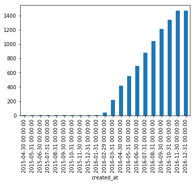

```python
## [conda ![](https://conda-forge.org/img/anvil_black.png) forge has had rapid growth in the past year and a half]()

        __import__('particles.Conda Forge');
```

```python
    kernels = Import('.Number of Kernels')
```

There are 95 Jupyter kernels

| Name | Jupyter/IPython Version | Language(s) Version | 3rd party dependencies | Example Notebooks | Notes |
| --- | --- | --- | --- | --- | --- |
| Coarray-Fortran | Jupyter 4.0 | Fortran 2008/2015 | GFortran >= 7.1, OpenCoarrays, MPICH >= 3.2 | Demo, Binder demo | Docker image |
| sparkmagic | Jupyter >=4.0 | Pyspark (Python 2 & 3), Spark (Scala), SparkR (R) | Livy | Notebooks, Docker Images | This kernels are implemented via the magics ma... |
| sas_kernel | Jupyter 4.0 | python >= 3.3 | SAS 9.4 or higher | NaN | NaN |
| IPyKernel | Jupyter 4.0 | python 2.7, >= 3.3 | pyzmq | NaN | NaN |
| IJulia | NaN | julia >= 0.3 | NaN | NaN | NaN |
| IHaskell | NaN | ghc >= 7.6 | NaN | NaN | NaN |
| IRuby | NaN | ruby >= 2.1 | NaN | NaN | NaN |
| IJavascript | NaN | nodejs >= 0.10 | NaN | NaN | NaN |
| jpCoffeescript | NaN | coffeescript >= 1.7 | NaN | NaN | NaN |
| ICSharp | Jupyter 4.0 | C# 4.0+ | scriptcs | NaN | NaN |
| IRKernel | IPython 3.0 | R 3.2 | rzmq | NaN | NaN |
| SageMath | Jupyter 4 | Any | many | NaN | NaN |
| pari_jupyter | Jupyter 4 | 2.8 | Cython | NaN | NaN |
| IFSharp | IPython 2.0 | F# | NaN | Features | NaN |
| gopherlab | Jupyter 4.1, JupyterLab | Go >= 1.6 | ZeroMQ (4.x) | examples | NaN |
| Gophernotes | Jupyter 4 | Go >= 1.4 | zeromq 2.2.x | examples | docker image |
| IGo | NaN | Go >= 1.4 | NaN | NaN | NaN |
| IScala | NaN | Scala | NaN | NaN | NaN |
| Jupyter-scala | IPython>=3.0 | Scala>=2.10 | NaN | example | NaN |
| IErlang | IPython 2.3 | Erlang | rebar | NaN | NaN |
| ITorch | IPython >= 2.2 | Torch 7 (LuaJIT) | NaN | NaN | NaN |
| IElixir | Jupyter < 6.0 | Elixir < 1.5 | Erlang OTP <= 19.3, Rebar | example | IElixir Notebook in Docker |
| ierl | Jupyter >= 4.0 | Erlang 19 or 20, Elixir 1.4 or 1.5, LFE 1.2 | Erlang, (optional) Elixir | NaN | NaN |
| IAldor | IPython >= 1 | Aldor | NaN | NaN | NaN |
| IOCaml | IPython >= 1.1 | OCaml >= 4.01 | opam | NaN | NaN |
| IForth | IPython >= 3 | Forth | NaN | NaN | NaN |
| IPerl | NaN | Perl 5 | NaN | NaN | NaN |
| IPerl6 | NaN | Perl 6 | NaN | NaN | NaN |
| Jupyter-Perl6 | Jupyter | Perl 6.C | Rakudo Perl 6 | NaN | NaN |
| IPHP | IPython >= 2 | PHP >= 5.4 | composer | NaN | DEPRECATED, use Jupyter-PHP |

[output cut: 65 more lines]

# Media

> Media is information that triggers the senses. The best science happens in person

```python
    from renci.style import *
    %load_ext literacy.template
```

*Media* & Culture

We measure cultures based on their articles or remaining media.

```
Import('.Moma');
```

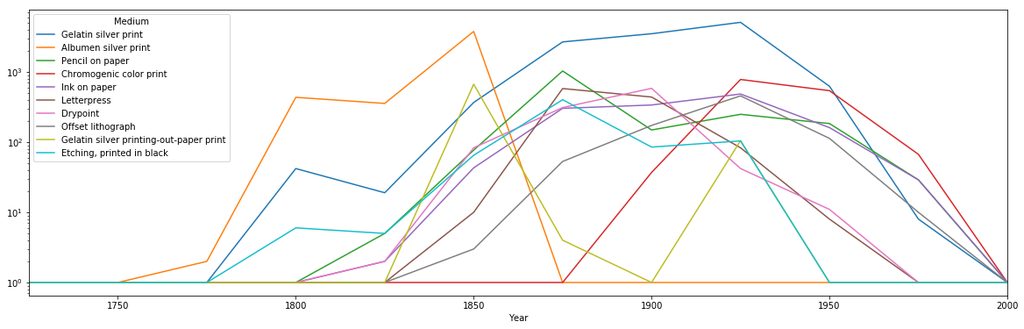

```python
## _Media_ & [Culture]()

We measure cultures based on their articles or remaining media.

    Import('.Moma');
```

```python
## _Media_ & [Design]()


* Bauhaus
* Powers of Ten
* Warhol Factory
* Beautiful Losers
* MIT Digital Media Lab
```

*Media* & Design

- Bauhaus

- Powers of Ten

- Warhol Factory

- Beautiful Losers

- MIT Digital Media Lab

```python
## _Media_ & [Systems]()
```

*Media* & Systems

```python
## _Media_ & [Materials]()
```

*Media* & Materials

```python
http://www.oreilly.com/programming/free/
```

[interactive chart not shown]

```python
# [Python Data Science Handbook](https://github.com/jakevdp/PythonDataScienceHandbook)
```

[Python Data Science Handbook](https://github.com/jakevdp/PythonDataScienceHandbook)

```python
http://nbviewer.jupyter.org/github/jakevdp/PythonDataScienceHandbook/blob/master/notebooks/00.00-Preface.ipynb#What-Is-Data-Science?
```

[interactive chart not shown]

```python
## _Media_ & [Community]()
```

*Media* & Community

```python
https://en.m.wikipedia.org/wiki/Library_of_Alexandria
```

[interactive chart not shown]

```python
https://www.loc.gov/
```

[interactive chart not shown]

```python
http://www.pewinternet.org/2016/09/09/americans-attitudes-toward-public-libraries/
```

[interactive chart not shown]

```python
[](https://www.ncbi.nlm.nih.gov/pmc/articles/PMC5584989/ "2017")
```

[interactive chart not shown]

```python
### Styleguides


# [PEP8](https://www.python.org/dev/peps/pep-0008/)
```

Styleguides

[PEP8](https://www.python.org/dev/peps/pep-0008/)

```python
    import this
```

```
import this
```

```
The Zen of Python, by Tim Peters

Beautiful is better than ugly.
Explicit is better than implicit.
Simple is better than complex.
Complex is better than complicated.
Flat is better than nested.
Sparse is better than dense.
Readability counts.
Special cases aren't special enough to break the rules.
Although practicality beats purity.
Errors should never pass silently.
Unless explicitly silenced.
In the face of ambiguity, refuse the temptation to guess.
There should be one-- and preferably only one --obvious way to do it.
Although that way may not be obvious at first unless you're Dutch.
Now is better than never.
Although never is often better than *right* now.
If the implementation is hard to explain, it's a bad idea.
If the implementation is easy to explain, it may be a good idea.
Namespaces are one honking great idea -- let's do more of those!
```

```python
https://en.m.wikipedia.org/wiki/The_Elements_of_Style
```

[interactive chart not shown]

```python
## [Mail Chimp Style Guide](https://github.com/mailchimp/content-style-guide)
```

[Mail Chimp Style Guide](https://github.com/mailchimp/content-style-guide)

```python
http://speaking.io
```

[interactive chart not shown]

```python
## _Media_ & [Media]()
```

*Media* & Media

```python
https://cdn.rawgit.com/ceteri/oriole_jupyterday_atl/master/oriole_talk.slides.html
```

[interactive chart not shown]

```python
## [Carol Willing's JupyterCon 2017 Talk](https://www.slideshare.net/willingc/jupyter-and-music)
```

[Carol Willing's JupyterCon 2017 Talk](https://www.slideshare.net/willingc/jupyter-and-music)

```python
http://nbviewer.jupyter.org/github/tensorflow/magenta-demos/blob/master/jupyter-notebooks/NSynth.ipynb#Part-2:-Timestretching
```

[interactive chart not shown]

```python
## [LIGO Notebooks](https://losc.ligo.org/tutorials/)
```

[LIGO Notebooks](https://losc.ligo.org/tutorials/)

[interactive chart not shown]

```python
<blockquote class="twitter-tweet" data-lang="en"><p lang="en" dir="ltr">The new NBA <a href="https://t.co/RkV6PkwXaD">pic.twitter.com/RkV6PkwXaD</a></p>&mdash; Mark Cuban (@mcuban) <a href="https://twitter.com/mcuban/status/846781342083923969?ref_src=twsrc%5Etfw">March 28, 2017</a></blockquote>
<script async src="https://platform.twitter.com/widgets.js" charset="utf-8"></script>
```

> The new NBA [pic.twitter.com/RkV6PkwXaD](https://t.co/RkV6PkwXaD)

> — Mark Cuban (@mcuban) [March 28, 2017](https://twitter.com/mcuban/status/846781342083923969?ref_src=twsrc%5Etfw)

# Culture

> Culture changes with time.

The modern, machine-assisted cultural infrastructure for open knowledge is:

- persistent
- (human, computer) language agnostic
- multi-domain
- built on volunteer effort
- decentralized
- open source

```python
    %load_ext literacy.template
    from renci.style import *
```

```python
## _Culture_ & [Design]()
```

*Culture* & Design

```python
> ### [Brand Identities like Facebook and CocaCola are the new colors.](https://brandcolors.net/c/google,home-depot,coca-cola,t-mobile,facebook,mailchimp)
```

> [Brand Identities like Facebook and CocaCola are the new colors.](https://brandcolors.net/c/google,home-depot,coca-cola,t-mobile,facebook,mailchimp)

[interactive chart not shown]

```python
# Color Picker <input type="color" name="favcolor" value="#ff0000">

    __import__("ipywidgets").ColorPicker()
```

Color Picker

```
__import__("ipywidgets").ColorPicker()
```

```python
> Now when I see people with Jupyter on their laptops I ask what they are doing.
```

> Now when I see people with Jupyter on their laptops I ask what they are doing.

```python
## _Culture_ & [Systems]()
```

*Culture* & Systems

```python
https://en.wikipedia.org/wiki/The_Mother_of_All_Demos
```

[interactive chart not shown]

> So in my office I have a console like this, and there are 12 others that are computer supplies.  
> And we try now-a-days to do our daily work on here. **So this characterizes the way I could sit here and look at a clear blank piece of paper, that's the way I start many projects.** So with my system, I start and say "I'd like to load that in." So, sorry about that. So I'm putting in an entity called a "statement." And this is full of other entities called "words." **If I make some mistakes I can back up a little bit.** So I have a statement with some entities, words, and I can do some operations on these and copy a word, and that word might copy after itself. In fact, a pair word I like to copy after itself. And I can just do this a few times, and get a bit of material there. And there are other materials, like "text." I can copy from that oint to that point. **It's copy.** So I can **get myself some material on my blank piece of paper** and say, "Well, this is going to be more important than it looks, so I'd like to set up a file." So I tell the machine, "Output to a file." And it says, "Well, I need a name." I'll give it a name. I'll say it's "sample file." And I'll say "Please output it", and it did! [A 7 year old github repo](https://github.com/atduskgreg/MoAD-Transcript/blob/master/20101020_moad_transcription_draft.txt#L7)

```python
https://en.wikipedia.org/wiki/Read%E2%80%93eval%E2%80%93print_loop
```

[interactive chart not shown]

```python
https://en.wikipedia.org/wiki/SageMath
```

[interactive chart not shown]

```python
#     webrtc = __import__('particles.webrtc')
```

webrtc = **import**('particles.webrtc')

```python
## _Culture_ & [Materials]()

![](https://images.gr-assets.com/authors/1340706964p4/3004479.jpg)

> ### The best things in life are free. The second best things are very, very expensive.
```

*Culture* & Materials

[figure not shown]

> The best things in life are free. The second best things are very, very expensive.

```python
- Github
- Binder
```

- Github

- Binder

```python
## _Culture_ & [Community]()

### [Contributors](https://github.com/jupyter/notebook/graphs/contributors)

### [Code of Conduct](https://github.com/jupyter/governance/blob/master/conduct/code_of_conduct.md)

### [Internationalization](https://github.com/jupyter/notebook/pull/2140 "JEP")

### [https://github.com/JuliaLang/julia/issues/4774](juliacon talk on an issue)
```

*Culture* & Community

[Contributors](https://github.com/jupyter/notebook/graphs/contributors)

[Code of Conduct](https://github.com/jupyter/governance/blob/master/conduct/code_of_conduct.md)

[Internationalization](https://github.com/jupyter/notebook/pull/2140)

https://github.com/JuliaLang/julia/issues/4774

```python
## _Culture_ & [Media]()
```

*Culture* & Media

```python
Jupyter days: Atlanta, Boston, Chicago, Hawaii, Philadelphia, Mountain View
```

Jupyter days: Atlanta, Boston, Chicago, Hawaii, Philadelphia, Mountain View

```python
Jupytercon
```

Jupytercon

```python
[nbviewer](https://nbviewer.org)
```

[nbviewer](https://nbviewer.org)

[interactive chart not shown]

```python
`Import('.Number of Notebooks').view`
```

`Import('.Number of Notebooks').view`

[interactive chart not shown]

```python
## _Culture_ & [Culture]()

- Open Source Software and Citizen Science is a life~~style~~.
```

*Culture* & Culture

- Open Source Software and Citizen Science is a lifestyle.

```python
https://en.m.wikipedia.org/wiki/24-hour_news_cycle
```

[interactive chart not shown]

```python
import style
```